# HomeWork3

## HomeWork3

### 1. Data preparation and Exploration

#### a) Selecting training data

Select the 50% data randomly for training and remaining for validation

```r
set.seed(55)
data_set <- read.table("SA-heart-data.csv", sep = "," , header = TRUE)
training_index <- sample(1:nrow(data_set), 231, replace = FALSE)
training_set <- data_set[training_index,]
validation_set <- data_set[-training_index,]
```

#### b) Data Exploration

Remove the first column from training and validation set. Then, see the one variable summary for training data.

```r
training_set <- training_set[,-1]
validation_set <- validation_set[,-1]
summary(training_set)
```

```
##       sbp           tobacco            ldl           adiposity
##  Min.   :101.0   Min.   : 0.000   Min.   : 0.980   Min.   : 7.12
##  1st Qu.:122.5   1st Qu.: 0.045   1st Qu.: 3.165   1st Qu.:19.57
##  Median :132.0   Median : 2.000   Median : 4.340   Median :26.13
##  Mean   :137.5   Mean   : 3.537   Mean   : 4.700   Mean   :25.25
##  3rd Qu.:148.0   3rd Qu.: 5.450   3rd Qu.: 5.765   3rd Qu.:31.32
##  Max.   :218.0   Max.   :27.400   Max.   :15.330   Max.   :42.49
##     famhist        typea          obesity         alcohol
##  Absent :131   Min.   :13.00   Min.   :17.89   Min.   :  0.00
##  Present:100   1st Qu.:46.00   1st Qu.:22.78   1st Qu.:  0.00
##                Median :52.00   Median :25.81   Median :  4.53
##                Mean   :52.37   Mean   :26.08   Mean   : 14.71
##                3rd Qu.:59.00   3rd Qu.:28.39   3rd Qu.: 21.55
##                Max.   :78.00   Max.   :46.58   Max.   :147.19
##       age             chd
##  Min.   :15.00   Min.   :0.000
##  1st Qu.:31.50   1st Qu.:0.000
##  Median :45.00   Median :0.000
##  Mean   :42.97   Mean   :0.316
##  3rd Qu.:56.00   3rd Qu.:1.000
##  Max.   :64.00   Max.   :1.000
```

Two Variable Summary Statistics :

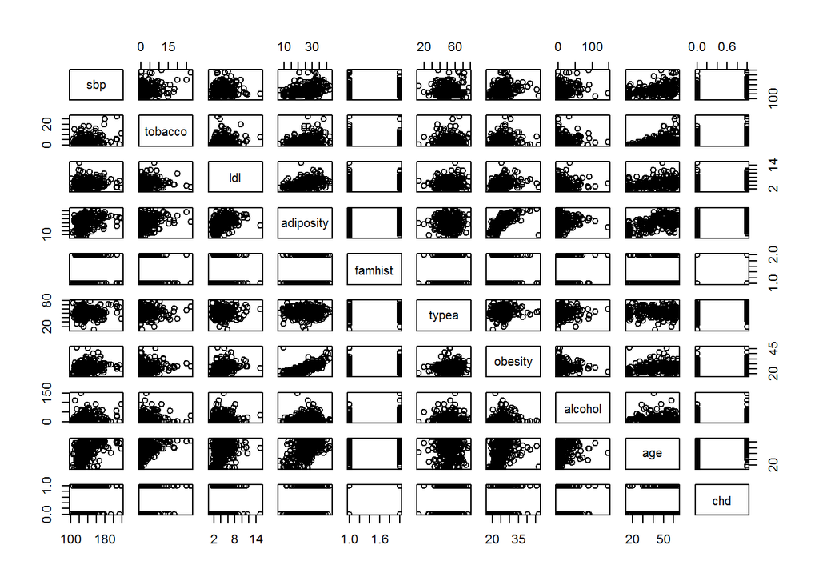

```r
pairs(training_set) #scatter-plot
```

Checking correlation and converting categorical predictor famhist to numeric as {1 or 2}:

```r
training_set$famhist <- as.numeric(training_set$famhist)
validation_set$famhist <- as.numeric(validation_set$famhist)
cor(training_set) # correlation between features and label
```

```
##                  sbp    tobacco         ldl  adiposity    famhist
## sbp       1.00000000 0.25999796  0.11558693 0.36424237 0.11776858
## tobacco   0.25999796 1.00000000  0.16509718 0.31981442 0.06899606
## ldl       0.11558693 0.16509718  1.00000000 0.43181464 0.18367837
## adiposity 0.36424237 0.31981442  0.43181464 1.00000000 0.20680585
## famhist   0.11776858 0.06899606  0.18367837 0.20680585 1.00000000
## typea     0.01732777 0.03800291  0.12683478 0.01489475 0.06274044
## obesity   0.23334750 0.17069586  0.32981035 0.70455697 0.17820771
## alcohol   0.16788547 0.12961364 -0.03411632 0.14250978 0.06946497
## age       0.41998890 0.47593099  0.31864061 0.58926670 0.26753864
## chd       0.26734785 0.31587550  0.25261979 0.29772364 0.30816574
##                 typea    obesity     alcohol         age        chd
## sbp        0.01732777 0.23334750  0.16788547  0.41998890 0.26734785
## tobacco    0.03800291 0.17069586  0.12961364  0.47593099 0.31587550
## ldl        0.12683478 0.32981035 -0.03411632  0.31864061 0.25261979
## adiposity  0.01489475 0.70455697  0.14250978  0.58926670 0.29772364
## famhist    0.06274044 0.17820771  0.06946497  0.26753864 0.30816574
## typea      1.00000000 0.09821164 -0.01055254 -0.01601797 0.13709080
## obesity    0.09821164 1.00000000  0.05231157  0.27755803 0.19083025
## alcohol   -0.01055254 0.05231157  1.00000000  0.16761440 0.08785111
## age       -0.01601797 0.27755803  0.16761440  1.00000000 0.38048251
## chd        0.13709080 0.19083025  0.08785111  0.38048251 1.00000000
```

We can see that famhist, age and tobacco are highly correlated to chd

Let’s check any missing values:

```r
any(is.na(training_set))
```

```
## [1] FALSE
```

There is no missing value

Outliers:

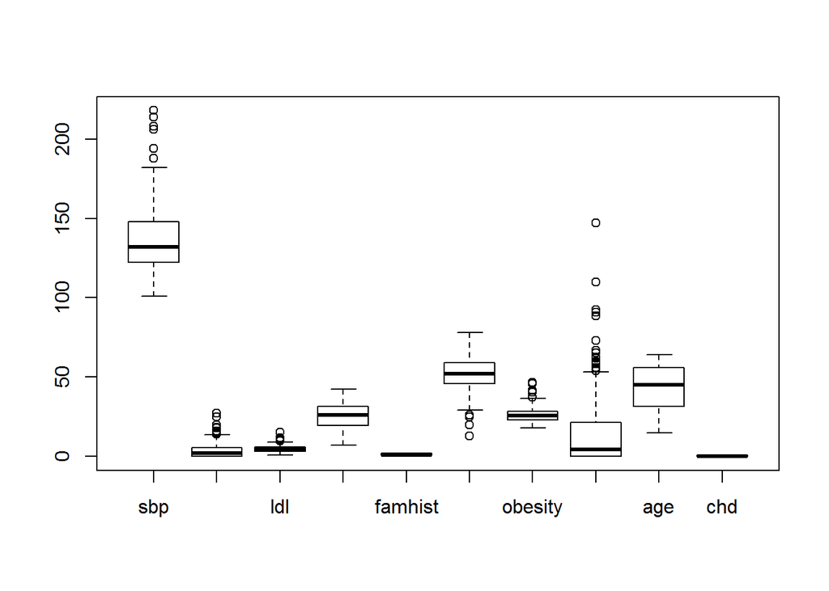

```r
boxplot(training_set)
```

As we can see, there are some values outside box but we will proceed these values as rare data points.

### 2)

#### Logistic Regression on training set

Make Logistic model with all predictors

```r
chd.out <- glm(chd ~ sbp + tobacco + ldl + adiposity + famhist + typea + obesity + alcohol + age, data = training_set, family = binomial())
summary(chd.out)
```

```
##
## Call:
## glm(formula = chd ~ sbp + tobacco + ldl + adiposity + famhist +
##     typea + obesity + alcohol + age, family = binomial(), data = training_set)
##
## Deviance Residuals:
##     Min       1Q   Median       3Q      Max
## -1.9977  -0.7594  -0.4194   0.8202   2.7944
##
## Coefficients:
##              Estimate Std. Error z value Pr(>|z|)
## (Intercept) -9.430832   1.958871  -4.814 1.48e-06 ***
## sbp          0.012280   0.008300   1.479 0.139011
## tobacco      0.094410   0.041069   2.299 0.021515 *
## ldl          0.115917   0.081722   1.418 0.156065
## adiposity    0.013146   0.042749   0.308 0.758459
## famhist      1.166792   0.341526   3.416 0.000635 ***
## typea        0.035472   0.017386   2.040 0.041329 *
## obesity      0.003643   0.061845   0.059 0.953022
## alcohol      0.003084   0.006969   0.443 0.658092
## age          0.040483   0.017802   2.274 0.022960 *
## ---
## Signif. codes:  0 '***' 0.001 '**' 0.01 '*' 0.05 '.' 0.1 ' ' 1
##
## (Dispersion parameter for binomial family taken to be 1)
##
##     Null deviance: 288.21  on 230  degrees of freedom
## Residual deviance: 219.94  on 221  degrees of freedom
## AIC: 239.94
##
## Number of Fisher Scoring iterations: 5
```

#### Variable Selection using all subset selection

Using leaps library, we will run exhaustive method to get all subset selection

```r
require(leaps)
exhaustive <- regsubsets(chd~.,data = training_set, method = "exhaustive")
summ.exhaustive <- summary(exhaustive)
summ.exhaustive
```

```
## Subset selection object
## Call: regsubsets.formula(chd ~ ., data = training_set, method = "exhaustive")
## 9 Variables  (and intercept)
##           Forced in Forced out
## sbp           FALSE      FALSE
## tobacco       FALSE      FALSE
## ldl           FALSE      FALSE
## adiposity     FALSE      FALSE
## famhist       FALSE      FALSE
## typea         FALSE      FALSE
## obesity       FALSE      FALSE
## alcohol       FALSE      FALSE
## age           FALSE      FALSE
## 1 subsets of each size up to 8
## Selection Algorithm: exhaustive
##          sbp tobacco ldl adiposity famhist typea obesity alcohol age
## 1  ( 1 ) " " " "     " " " "       " "     " "   " "     " "     "*"
## 2  ( 1 ) " " " "     " " " "       "*"     " "   " "     " "     "*"
## 3  ( 1 ) " " "*"     " " " "       "*"     " "   " "     " "     "*"
## 4  ( 1 ) " " "*"     " " " "       "*"     "*"   " "     " "     "*"
## 5  ( 1 ) "*" "*"     " " " "       "*"     "*"   " "     " "     "*"
## 6  ( 1 ) "*" "*"     "*" " "       "*"     "*"   " "     " "     "*"
## 7  ( 1 ) "*" "*"     "*" "*"       "*"     "*"   " "     " "     "*"
## 8  ( 1 ) "*" "*"     "*" "*"       "*"     "*"   " "     "*"     "*"
```

Graph below showing best set of parameters for each number of selection of parameters

We will find it using Minimum BIC value

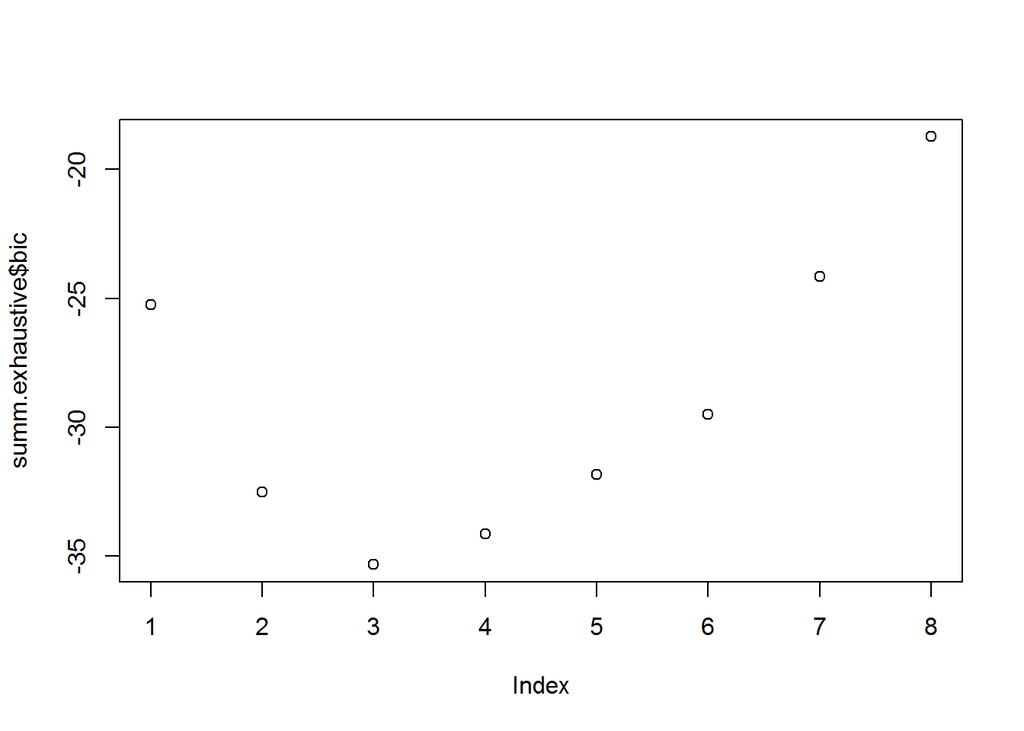

```r
plot(summ.exhaustive$bic)
```

We can see that minimum value of bic is for 3 parameters. So using exhaustive summary, we can select tobacco, famhist and age.

Model with predictors through all subset selection and BIC:

```r
bic.model <- glm(chd~age+tobacco + famhist, data = training_set, family = binomial())
summary(bic.model)
```

```
##
## Call:
## glm(formula = chd ~ age + tobacco + famhist, family = binomial(),
##     data = training_set)
##
## Deviance Residuals:
##     Min       1Q   Median       3Q      Max
## -1.8643  -0.8025  -0.4169   0.9365   2.5581
##
## Coefficients:
##             Estimate Std. Error z value Pr(>|z|)
## (Intercept) -5.30764    0.83916  -6.325 2.53e-10 ***
## age          0.05043    0.01457   3.460 0.000540 ***
## tobacco      0.09773    0.03889   2.513 0.011964 *
## famhist      1.21711    0.32922   3.697 0.000218 ***
## ---
## Signif. codes:  0 '***' 0.001 '**' 0.01 '*' 0.05 '.' 0.1 ' ' 1
##
## (Dispersion parameter for binomial family taken to be 1)
##
##     Null deviance: 288.21  on 230  degrees of freedom
## Residual deviance: 231.27  on 227  degrees of freedom
## AIC: 239.27
##
## Number of Fisher Scoring iterations: 5
```

### 3) Fitting LDA on training set

```r
require(MASS)
X <- as.matrix(training_set[,-10])
Y <- as.matrix(training_set[,10])
lda.model <- lda(x = X, grouping = Y ,cv = TRUE)
```

### 4) Lasso Regularization

Use glmnet for lasso model. Provide lambad range from 10^10 to 10^-2

```r
require(glmnet)
lambda.range <- 10^seq(10, -2, length =100)
lasso.model <- glmnet(X, Y, lambda = lambda.range)
```

#### a) Plot of path of individual coefficients

Plotting the path for coefficients for different lambda values. X - axis scale is limited to (-5,5)

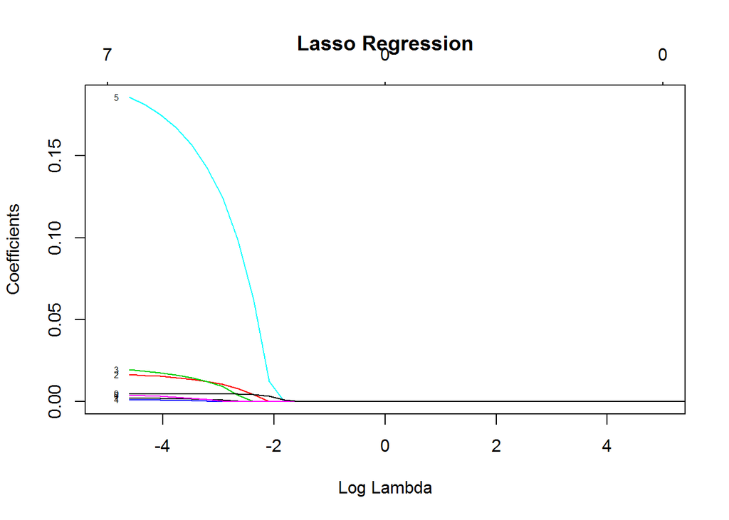

```r
plot(lasso.model,main = "Lasso Regression", label = TRUE, xvar ='lambda', xlim = c(-5,5))
```

#### b) Cross Validation

We will use cross validation to find best lambda value.

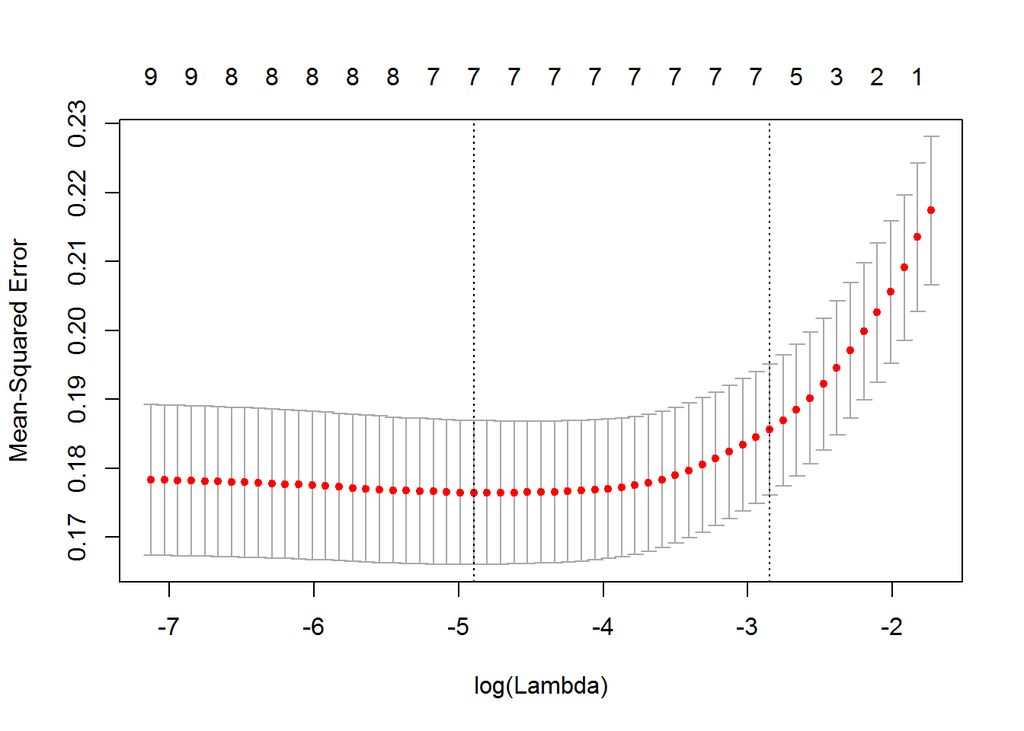

```r
cv.out <- cv.glmnet(X, Y)
plot(cv.out)
```

Graph above shows the parameter versus mean squared error graph using cross validation model. Range of log of lambda is shown as -2.9 to -4.9 in the graph.

#### c) Regularization parameter

```r
best.lambda <- cv.out$lambda.min
best.lambda
```

```
## [1] 0.00748127
```

```r
lasso.cv.model <- glmnet(X,Y,lambda = best.lambda) # Model with best lambda
```

Minimum lamda return is 0.00748127. We will build model using this lambda.

#### d) Selected Predictor model

Checking coefficients of lasso.cv.model

```r
coefficients(lasso.cv.model)
```

```
## 10 x 1 sparse Matrix of class "dgCMatrix"
##                       s0
## (Intercept) -0.867635932
## sbp          0.002262406
## tobacco      0.016819326
## ldl          0.020016853
## adiposity    0.001256398
## famhist      0.189273244
## typea        0.004082509
## obesity      .
## alcohol      .
## age          0.004709021
```

Removing obesity and alcohol as it is null and only ldl, tobacco and famhist has values significantly greater than 0. So, we will build the model using ldl, tobacco and famhist as predictors.

```r
best.lasso <- glm(chd~ldl +famhist + tobacco, data = training_set, family = binomial())
```

### 5) Nearest Shrunken Centroid Model

#### a) Cross Validation to select best regularization parameter

First we will train the model on data using pamr.train. Then, we will use cross validation over the 30 values of thresholds to plot the graph for those.

```r
library(pamr)
data.train <- list(x =X, y =Y, genenames=as.character(1:1000))
centroid.model <- pamr.train(data.train)
```

```
## 123456789101112131415161718192021222324252627282930
```

```r
cv.out.pamr <- pamr.cv(centroid.model, data.train)
```

```
## 12Fold 1 :123456789101112131415161718192021222324252627282930
## Fold 2 :123456789101112131415161718192021222324252627282930
## Fold 3 :123456789101112131415161718192021222324252627282930
```

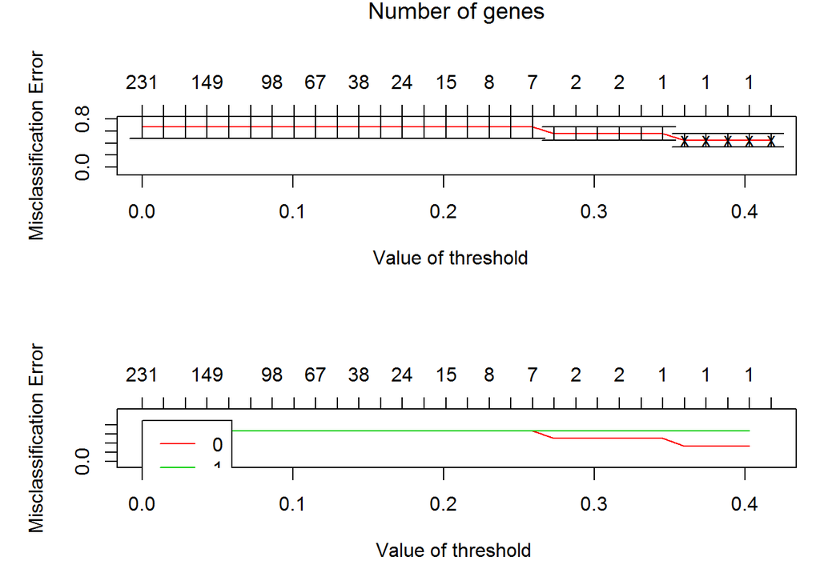

```r
pamr.plotcv(cv.out.pamr)
```

Graph is showing to have the value of threshold from 0.18 to 0.42. We will use confusion to find best threshold.

```r
pamr.confusion(cv.out.pamr, threshold = 0.15)
```

```
##   0 1 Class Error rate
## 0 2 4        0.6666667
## 1 2 1        0.6666667
## Overall error rate= 0.581
```

```r
pamr.confusion(cv.out.pamr, threshold = 0.18)
```

```
##   0 1 Class Error rate
## 0 2 4        0.6666667
## 1 2 1        0.6666667
## Overall error rate= 0.581
```

```r
pamr.confusion(cv.out.pamr, threshold = 0.2)
```

```
##   0 1 Class Error rate
## 0 2 4        0.6666667
## 1 2 1        0.6666667
## Overall error rate= 0.581
```

```r
pamr.confusion(cv.out.pamr, threshold = 0.25)
```

```
##   0 1 Class Error rate
## 0 2 4        0.6666667
## 1 2 1        0.6666667
## Overall error rate= 0.581
```

```r
pamr.confusion(cv.out.pamr, threshold = 0.3)
```

```
##   0 1 Class Error rate
## 0 3 3        0.5000000
## 1 2 1        0.6666667
## Overall error rate= 0.492
```

```r
pamr.confusion(cv.out.pamr, threshold = 0.35)
```

```
##   0 1 Class Error rate
## 0 4 2        0.3333333
## 1 2 1        0.6666667
## Overall error rate= 0.4
```

```r
pamr.confusion(cv.out.pamr, threshold = 0.4)
```

```
##   0 1 Class Error rate
## 0 4 2        0.3333333
## 1 2 1        0.6666667
## Overall error rate= 0.4
```

#### b) Refit the model with selected regularized parameter

```r
centroid.model.best <- pamr.train(data.train, threshold =  0.18)
```

```
## 1
```

#### c) Visualize the centroids of the selected model

Visualizing the centroids using plotcen

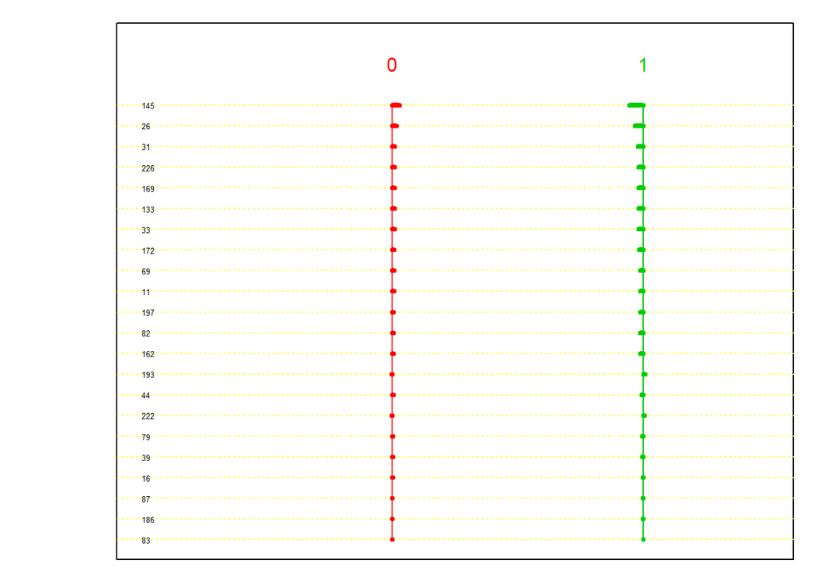

```r
pamr.plotcen(centroid.model.best, data.train, threshold = 0.18)
```

#### 6 Evaluate the performance of classifiers

### a) Performance of classifiers using ROC curves on the training set

## For Logistic model with all predictors

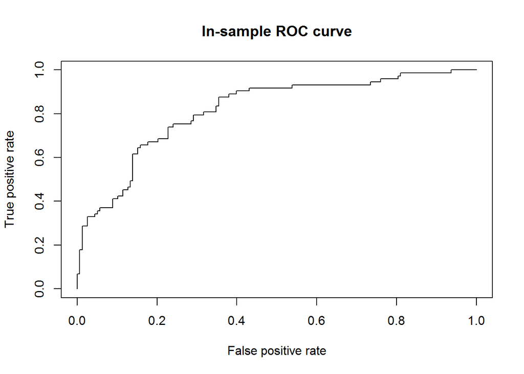

```r
library(ROCR)
scores <- predict(chd.out, newdata= training_set , type="response") # predicted prob
pred <- prediction(scores, labels=training_set$chd)
# comparing pred prob to label
perf <- performance(pred, "tpr", "fpr")
# plot the ROC curve
plot(perf, colorize=F, main="In-sample ROC curve")
```

```r
#area under curve
unlist(attributes(performance(pred, "auc"))$y.values)
```

```
## [1] 0.8171493
```

So correctness of this model on training set is 81.71%

## For BIC model

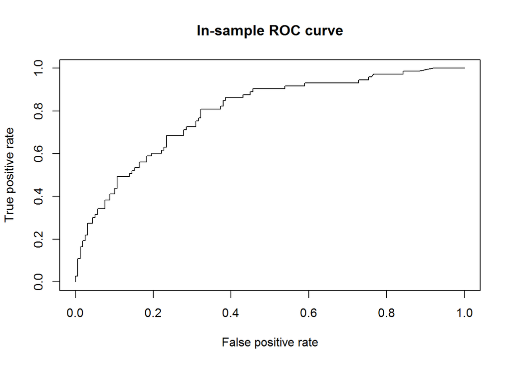

```r
scores_bic <- predict(bic.model, newdata= training_set, type = "response")
# predicted prob
pred_bic <- prediction(scores_bic, labels=training_set$chd)
# comparing pred prob to label
perf_bic <- performance(pred_bic, "tpr", "fpr")
# plot the ROC curve
plot(perf_bic, colorize=F, main="In-sample ROC curve")
```

```r
#area under curve
unlist(attributes(performance(pred_bic, "auc"))$y.values)
```

```
## [1] 0.7942171
```

Bic model predicts value with 79.42% accuracy

## For Lasso model

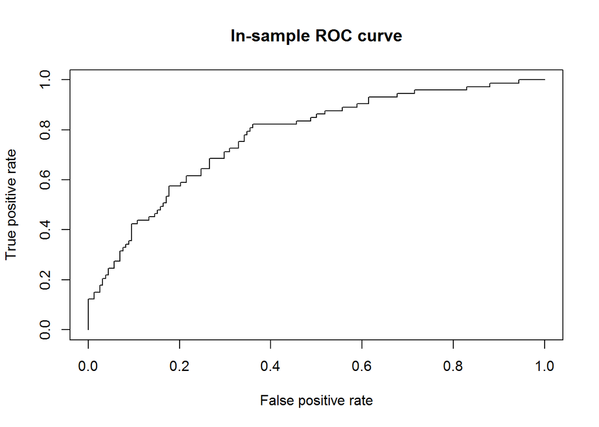

```r
scores_lasso <- predict(best.lasso, newdata= training_set, type = "response")
# predicted prob
pred_lasso <- prediction(scores_lasso, labels=training_set$chd)
# comparing pred prob to label
perf_lasso <- performance(pred_lasso, "tpr", "fpr")
# plot the ROC curve
plot(perf_lasso, colorize=F, main="In-sample ROC curve")
```

```r
#area under curve
unlist(attributes(performance(pred_lasso, "auc"))$y.values)
```

```
## [1] 0.7718051
```

There is 77.18% accuracy from Lasso model

### 6b) ROC on validation set

For Logistic model on all predictors

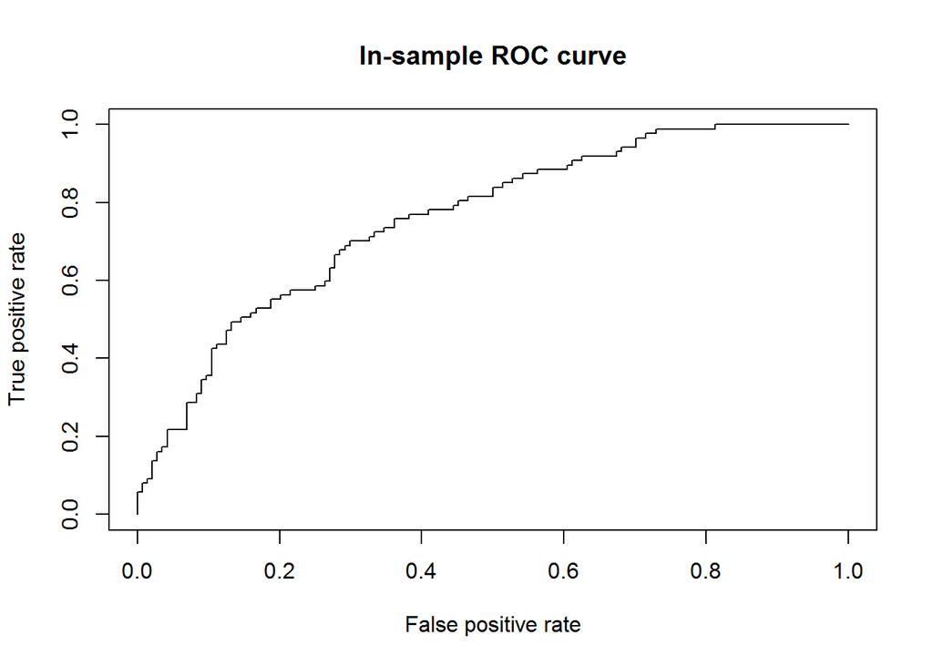

```r
scores <- predict(chd.out, newdata= validation_set , type="response") # predicted prob
pred <- prediction(scores, labels=validation_set$chd)
# comparing pred prob to label
perf <- performance(pred, "tpr", "fpr")
# plot the ROC curve
plot(perf, colorize=F, main="In-sample ROC curve")
```

```r
#area under curve
unlist(attributes(performance(pred, "auc"))$y.values)
```

```
## [1] 0.7600575
```

## For BIC model

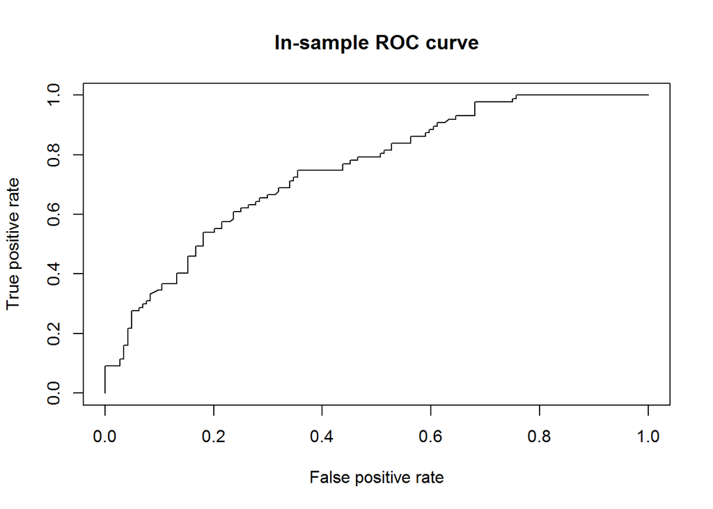

```r
scores_bic <- predict(bic.model, newdata= validation_set, type = "response")
# predicted prob
pred_bic <- prediction(scores_bic, labels=validation_set$chd)
# comparing pred prob to label
perf_bic <- performance(pred_bic, "tpr", "fpr")
# plot the ROC curve
plot(perf_bic, colorize=F, main="In-sample ROC curve")
```

```r
#area under curve
unlist(attributes(performance(pred_bic, "auc"))$y.values)
```

```
## [1] 0.7507583
```

Bic model predicts value with 75.07% accuracy

## For Lasso model

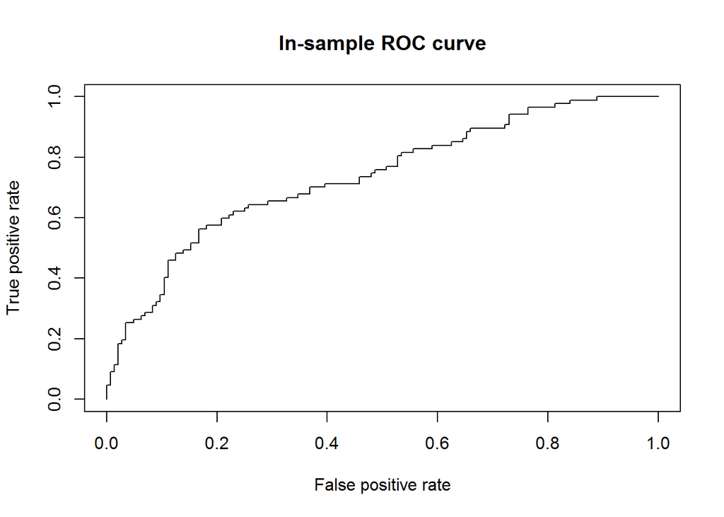

```r
scores_lasso <- predict(best.lasso, newdata= validation_set, type = "response")
# predicted prob
pred_lasso <- prediction(scores_lasso, labels=validation_set$chd)
# comparing pred prob to label
perf_lasso <- performance(pred_lasso, "tpr", "fpr")
# plot the ROC curve
plot(perf_lasso, colorize=F, main="In-sample ROC curve")
```

```r
#area under curve
unlist(attributes(performance(pred_lasso, "auc"))$y.values)
```

```
## [1] 0.7359515
```

There is 73.59% accuracy from Lasso model

6c) Summary For ROC :

On training set:

Logistic Model with all predictors: 81.71% BIC model : 79.42% Lasso Model: 77.18%

On validation set:

Logistic Model with all predictors: 76.00% BIC model : 75.07% Lasso Model: 73.59%

Accracy prediction is more on training set, but it’s not very much large from validation set. For ML model, accuracy on validation data is more considerable.